# Practical Machine Learning Assignment - Coursera

Gautam Mehra

12/17/2016

## Background

Using devices such as Jawbone Up, Nike FuelBand, and Fitbit it is now possible to collect a large amount of data about personal activity relatively inexpensively. One thing that people regularly do is quantify how much of a particular activity they do, but they rarely quantify how well they do it. In this project, your goal will be to use data from accelerometers on the belt, forearm, arm, and dumbell of 6 participants. They were asked to perform barbell lifts correctly and incorrectly in 5 different ways.

## Data Sources

The training data for this project are available here:

https://d396qusza40orc.cloudfront.net/predmachlearn/pml-training.csv

The test data are available here:

https://d396qusza40orc.cloudfront.net/predmachlearn/pml-testing.csv

## Loading the libraries

```r
library(caret); library(rpart); library(rattle); library(rpart.plot)
library(randomForest); library(repmis)
```

## Fetching The Data

Lets load the training data set first:

```r
trainUrl <- "http://d396qusza40orc.cloudfront.net/predmachlearn/pml-training.csv"
training <- read.csv(url(trainUrl), na.strings=c("NA","#DIV/0!",""))
```

Now, lets load the testing data set:

```r
testUrl <- "http://d396qusza40orc.cloudfront.net/predmachlearn/pml-testing.csv"
testing <- read.csv(url(testUrl), na.strings=c("NA","#DIV/0!",""))
```

## Cleaning the data

```r
training <- training[, colSums(is.na(training)) == 0]
testing <- testing[, colSums(is.na(testing)) == 0]
```

Now let’s remove the unneccessary predictors.

```r
training <- training[, -c(1:7)]
testing <- testing[, -c(1:7)]
```

While, we have downloaded the training and testing data sets seperately, we want to further split the training set into 2 subsets. We do this so that we can estimate the out-of-sample errors and hopefully pick an alogirthm that would predict better on the final testing data set.

```r
set.seed(1398)
inTrain <- createDataPartition(training$classe, p = 0.7, list = FALSE)
train <- training[inTrain, ]
valid <- training[-inTrain, ]
```

## Applying Machine Learnign Algortihms

What we have is a typical classification problem. Hence, we will use decision trees and random forests. These algorthms will be able to look at the large number of features present in the data set and predict the most appropriate class of the activity.

### Decision Tree

Let’s first look at the more simple decision tree. Since this is not a regression or other linear predictive alogirthm, we don’t need to peform transformations such as scaling and centering, which we normally would. So, lets straight get to it.

```r
rpart_model <- train(classe ~ ., data = train, method="rpart")
print(rpart_model, digits = 3)
```

```
## CART
##
## 13737 samples
##    52 predictor
##     5 classes: 'A', 'B', 'C', 'D', 'E'
##
## No pre-processing
## Resampling: Bootstrapped (25 reps)
## Summary of sample sizes: 13737, 13737, 13737, 13737, 13737, 13737, ...
## Resampling results across tuning parameters:
##
##   cp      Accuracy  Kappa
##   0.0362  0.506     0.3584
##   0.0600  0.400     0.1815
##   0.1129  0.335     0.0769
##
## Accuracy was used to select the optimal model using  the largest value.
## The final value used for the model was cp = 0.0362.
```

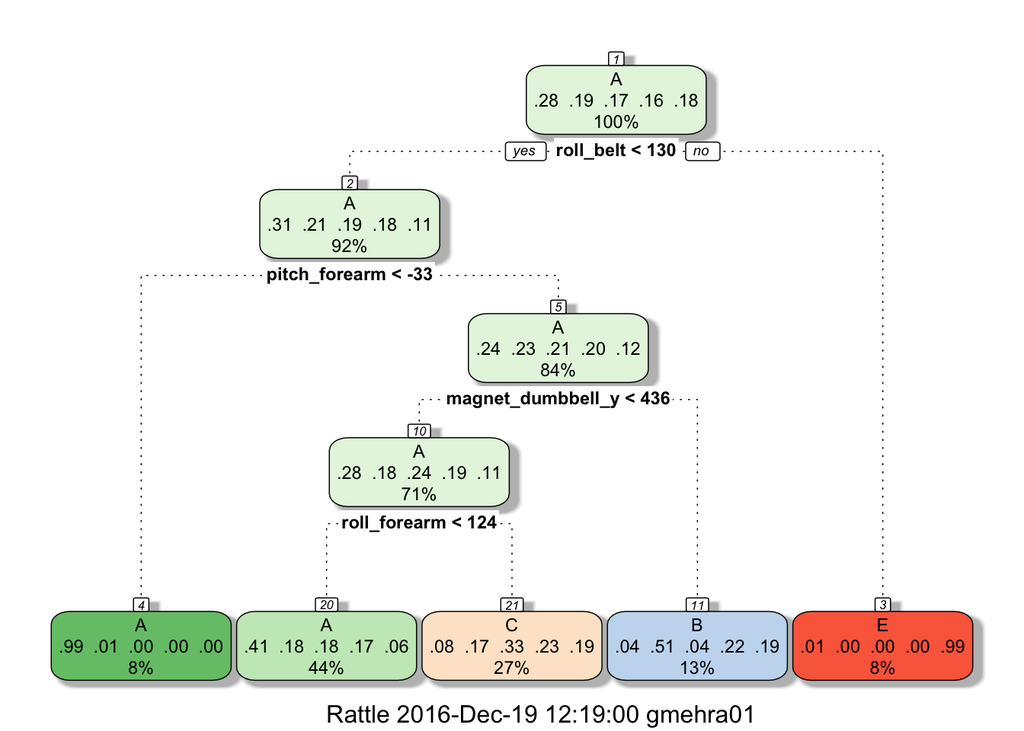

```r
fancyRpartPlot(rpart_model$finalModel)
```

Let’s see how it performs now.

```r
rpart_predict <- predict(rpart_model, valid)
rpart_matrix <- confusionMatrix(valid$classe, rpart_predict)
print(rpart_matrix)
```

```
## Confusion Matrix and Statistics
##
##           Reference
## Prediction    A    B    C    D    E
##          A 1534   23  114    0    3
##          B  459  397  283    0    0
##          C  483   37  506    0    0
##          D  436  186  342    0    0
##          E  155  147  270    0  510
##
## Overall Statistics
##
##                Accuracy : 0.5008
##                  95% CI : (0.4879, 0.5136)
##     No Information Rate : 0.5212
##     P-Value [Acc > NIR] : 0.9992
##
##                   Kappa : 0.3473
##  Mcnemar's Test P-Value : NA
##
## Statistics by Class:
##
##                      Class: A Class: B Class: C Class: D Class: E
## Sensitivity            0.5002  0.50253  0.33399       NA  0.99415
## Specificity            0.9503  0.85437  0.88101   0.8362  0.89352
## Pos Pred Value         0.9164  0.34855  0.49318       NA  0.47135
## Neg Pred Value         0.6360  0.91719  0.79234       NA  0.99938
## Prevalence             0.5212  0.13424  0.25743   0.0000  0.08717
## Detection Rate         0.2607  0.06746  0.08598   0.0000  0.08666
## Detection Prevalence   0.2845  0.19354  0.17434   0.1638  0.18386
## Balanced Accuracy      0.7252  0.67845  0.60750       NA  0.94384
```

```r
(accuracy_rpart <- rpart_matrix$overall[1])
```

```
##  Accuracy
## 0.5007647
```

Let’s try another classification alogirthm. Random Forests.

## Random Forests

Lets build our model.

```r
control <- trainControl(method = "cv", number = 2)
rf_model <- train(classe ~ ., data = train, method = "rf", trControl = control)
#rf_model <- randomForest(factor(classe) ~ ., data = train, ntree = 100)
print(rf_model, digits = 3)
```

```
## Random Forest
##
## 13737 samples
##    52 predictor
##     5 classes: 'A', 'B', 'C', 'D', 'E'
##
## No pre-processing
## Resampling: Cross-Validated (2 fold)
## Summary of sample sizes: 6868, 6869
## Resampling results across tuning parameters:
##
##   mtry  Accuracy  Kappa
##    2    0.984     0.980
##   27    0.986     0.982
##   52    0.977     0.971
##
## Accuracy was used to select the optimal model using  the largest value.
## The final value used for the model was mtry = 27.
```

```r
rf_predict <- predict(rf_model, valid)
rf_confusion <- confusionMatrix(valid$classe, rf_predict)
print(rf_confusion)
```

```
## Confusion Matrix and Statistics
##
##           Reference
## Prediction    A    B    C    D    E
##          A 1674    0    0    0    0
##          B    6 1130    3    0    0
##          C    0    2 1022    2    0
##          D    0    0   12  951    1
##          E    0    1    0    1 1080
##
## Overall Statistics
##
##                Accuracy : 0.9952
##                  95% CI : (0.9931, 0.9968)
##     No Information Rate : 0.2855
##     P-Value [Acc > NIR] : < 2.2e-16
##
##                   Kappa : 0.994
##  Mcnemar's Test P-Value : NA
##
## Statistics by Class:
##
##                      Class: A Class: B Class: C Class: D Class: E
## Sensitivity            0.9964   0.9974   0.9855   0.9969   0.9991
## Specificity            1.0000   0.9981   0.9992   0.9974   0.9996
## Pos Pred Value         1.0000   0.9921   0.9961   0.9865   0.9982
## Neg Pred Value         0.9986   0.9994   0.9969   0.9994   0.9998
## Prevalence             0.2855   0.1925   0.1762   0.1621   0.1837
## Detection Rate         0.2845   0.1920   0.1737   0.1616   0.1835
## Detection Prevalence   0.2845   0.1935   0.1743   0.1638   0.1839
## Balanced Accuracy      0.9982   0.9977   0.9924   0.9971   0.9993
```

```r
(accuracy_rf <- rf_confusion$overall[1])
```

```
##  Accuracy
## 0.9952421
```

We observed an accuracy of 0.995. This is a great number and a substantial increase from our classification tree. This is due to the fact that random forests use multiple trees and combine several weak models to create a strong prediction model which is less bias and more accurate.

## Prediction On The First Test Set

Since, our Random Forest model worked far better. We will use this for the now predicting against our test set.

```r
predict(rf_model, testing)
```

```
##  [1] B A B A A E D B A A B C B A E E A B B B
## Levels: A B C D E
```

This concludes our project.